# 065-253_L01-Cecilia-Lodron

Cecilia Lodron Gonzaga

2025-11-06

## 1. Matriz simples.

### a. Construa a matriz dada e denomine como minhaMat.

Resposta

```r
a <- c(6, 34, 923, 5, 0)
b <- c(112:116)
c <- c(5, 9, 34, 76, 2)
d <- c(545:549)
minhamat <- cbind(a, b, c, d)
minhamat
```

```
##        a   b  c   d
## [1,]   6 112  5 545
## [2,]  34 113  9 546
## [3,] 923 114 34 547
## [4,]   5 115 76 548
## [5,]   0 116  2 549
```

### b. Obtenha a média de cada linha.

Resposta

```r
apply(minhamat, 1, mean)
```

```
## [1] 167.00 175.50 404.50 186.00 166.75
```

### c. Obtenha a média de cada coluna.

Resposta

```r
apply(minhamat, 2, mean, na.rm = TRUE)
```

```
##     a     b     c     d
## 193.6 114.0  25.2 547.0
```

### d. Ordene as colunas em ordem ascendente

Resposta

```r
apply(minhamat, 2, sort)
```

```
##        a   b  c   d
## [1,]   0 112  2 545
## [2,]   5 113  5 546
## [3,]   6 114  9 547
## [4,]  34 115 34 548
## [5,] 923 116 76 549
```

### Use a função apply para executar a operação módulo da divisão por 10 em cada elemento da matriz (A nova matriz contém o resto da divisão por 10).

Resposta

```r
apply(minhamat, 1, function(x) x%%10)
```

```
##   [,1] [,2] [,3] [,4] [,5]
## a    6    4    3    5    0
## b    2    3    4    5    6
## c    5    9    4    6    2
## d    5    6    7    8    9
```

## 2. Conjunto de dados mtcars.

### a. Use três funções da família apply para o obter o mínimo de cada coluna do conjunto de dados. Armazene cada resultado em um objeto separado (l, s e m) e mostre suas saídas.

Resposta

```r
l <- apply(mtcars, 2, min) #retorna um vetor
s <- lapply(mtcars, min) #retorna uma lista
m <- sapply(mtcars, min) #retorna um vetor
l
```

```
##    mpg    cyl   disp     hp   drat     wt   qsec     vs     am   gear   carb
## 10.400  4.000 71.100 52.000  2.760  1.513 14.500  0.000  0.000  3.000  1.000
```

```r
s
```

```
## $mpg
## [1] 10.4
##
## $cyl
## [1] 4
##
## $disp
## [1] 71.1
##
## $hp
## [1] 52
##
## $drat
## [1] 2.76
##
## $wt
## [1] 1.513
##
## $qsec
## [1] 14.5
##
## $vs
## [1] 0
##
## $am
## [1] 0
##
## $gear
## [1] 3
##
## $carb
## [1] 1
```

```r
m
```

```
##    mpg    cyl   disp     hp   drat     wt   qsec     vs     am   gear   carb
## 10.400  4.000 71.100 52.000  2.760  1.513 14.500  0.000  0.000  3.000  1.000
```

### b. Coloque os três objetos l, s e m na lista lista.objetos.

Resposta

```r
lista.objetos <- list(l, s, m)
```

### c. Use uma função apply adequada para obter a classe de cada um dos três elementos da lista lista.objetos.

Resposta

```r
lapply(lista.objetos, class)
```

```
## [[1]]
## [1] "numeric"
##
## [[2]]
## [1] "list"
##
## [[3]]
## [1] "numeric"
```

### d. Qual a classe da saída de cada uma das três funções usadas no exercício?

Resposta “numeric” “list” “numeric”

### e. Repita o exercício usando estruturas de controle. Compare o tempo entre as duas abordagens (Estruturas de controle e família apply).

Resposta

```r
g <- function(lista) {
  classe <- vector("character", length(lista))
  for (i in 1:length(lista)) {
    classe[i] <- class(lista[[i]])
  }
  return(classe)
}

g(lista.objetos)
```

```
## [1] "numeric" "list"    "numeric"
```

```r
system.time(replicate(10000, lapply(lista.objetos, class)))
```

```
##   usuário   sistema decorrido
##      0.03      0.00      0.04
```

```r
system.time(replicate(10000,{
    classes <- character(length(lista.objetos))
    for (i in 1:length(lista.objetos)) {
      classes[i] <- class(lista.objetos[[i]])
    }
  }))
```

```
##   usuário   sistema decorrido
##      0.03      0.00      0.03
```

## 3. Função mapply.

### a. Use a função mapply para obter uma lista de 10 elementos. O primeiro elemento da lista é uma sequência de 10 caracteres “A”; a segunda, 9 caracteres “F”, que seguem alternando-se até o último elemento o qual possui um único caractere.

Resposta

```r
c <- rep(c("A", "F"), length.out = 10)
r <- 10:1

lista1 <- mapply(rep, c, r, SIMPLIFY = F)
lista1
```

```
## $A
##  [1] "A" "A" "A" "A" "A" "A" "A" "A" "A" "A"
##
## $F
## [1] "F" "F" "F" "F" "F" "F" "F" "F" "F"
##
## $A
## [1] "A" "A" "A" "A" "A" "A" "A" "A"
##
## $F
## [1] "F" "F" "F" "F" "F" "F" "F"
##
## $A
## [1] "A" "A" "A" "A" "A" "A"
##
## $F
## [1] "F" "F" "F" "F" "F"
##
## $A
## [1] "A" "A" "A" "A"
##
## $F
## [1] "F" "F" "F"
##
## $A
## [1] "A" "A"
##
## $F
## [1] "F"
```

### b. Ajuste a função para obter a numeração adequada de cada elemento da lista. Dica: argumento USE.NAMES

Resposta

```r
lista2<- mapply(rep, c, r, USE.NAMES = T, SIMPLIFY = F)
lista2
```

```
## $A
##  [1] "A" "A" "A" "A" "A" "A" "A" "A" "A" "A"
##
## $F
## [1] "F" "F" "F" "F" "F" "F" "F" "F" "F"
##
## $A
## [1] "A" "A" "A" "A" "A" "A" "A" "A"
##
## $F
## [1] "F" "F" "F" "F" "F" "F" "F"
##
## $A
## [1] "A" "A" "A" "A" "A" "A"
##
## $F
## [1] "F" "F" "F" "F" "F"
##
## $A
## [1] "A" "A" "A" "A"
##
## $F
## [1] "F" "F" "F"
##
## $A
## [1] "A" "A"
##
## $F
## [1] "F"
```

### c. Repita o exercício usando estruturas de controle. Compare o tempo entre as duas abordagens (Estruturas de controle e família apply).

Resposta

```r
f <- function(n) {
  c <- rep(c("A", "F"), length.out = n)
  r <- n:1
  lista <- vector("list", n)

  for (i in 1:n) {
    lista[[i]] <- rep(c[i], r[i])
  }
  return(lista)
}

lista3 <- f(10)
lista3
```

```
## [[1]]
##  [1] "A" "A" "A" "A" "A" "A" "A" "A" "A" "A"
##
## [[2]]
## [1] "F" "F" "F" "F" "F" "F" "F" "F" "F"
##
## [[3]]
## [1] "A" "A" "A" "A" "A" "A" "A" "A"
##
## [[4]]
## [1] "F" "F" "F" "F" "F" "F" "F"
##
## [[5]]
## [1] "A" "A" "A" "A" "A" "A"
##
## [[6]]
## [1] "F" "F" "F" "F" "F"
##
## [[7]]
## [1] "A" "A" "A" "A"
##
## [[8]]
## [1] "F" "F" "F"
##
## [[9]]
## [1] "A" "A"
##
## [[10]]
## [1] "F"
```

```r
system.time(replicate(10000, mapply(rep, c, r, USE.NAMES = T, SIMPLIFY = F)))
```

```
##   usuário   sistema decorrido
##      0.12      0.00      0.14
```

```r
system.time(replicate(10000, {
  c <- rep(c("A", "F"), length.out = 10)
  r <- 10:1
  lista <- vector("list", 10)

  for (i in 1:10) {
    lista[[i]] <- rep(c[i], r[i])
  }
}))
```

```
##   usuário   sistema decorrido
##      0.09      0.00      0.10
```

## 4. Sobrevivência dos passageiros do Titanic – conjunto de dados Titanic{datasets}:

### a. Use uma função apply apropriada para obter a soma de homens e mulheres à bordo.

Resposta

```r
apply(Titanic, 2, sum)
```

```
##   Male Female
##   1731    470
```

### b. Construa uma tabela com a soma de sobreviventes pela variável Sex.

Resposta

```r
head(Titanic)
```

```
## , , Age = Child, Survived = No
##
##       Sex
## Class  Male Female
##   1st     0      0
##   2nd     0      0
##   3rd    35     17
##   Crew    0      0
##
## , , Age = Adult, Survived = No
##
##       Sex
## Class  Male Female
##   1st   118      4
##   2nd   154     13
##   3rd   387     89
##   Crew  670      3
##
## , , Age = Child, Survived = Yes
##
##       Sex
## Class  Male Female
##   1st     5      1
##   2nd    11     13
##   3rd    13     14
##   Crew    0      0
##
## , , Age = Adult, Survived = Yes
##
##       Sex
## Class  Male Female
##   1st    57    140
##   2nd    14     80
##   3rd    75     76
##   Crew  192     20
```

```r
apply(Titanic, c(2, 4), sum)
```

```
##         Survived
## Sex        No Yes
##   Male   1364 367
##   Female  126 344
```

### c. Obtenha uma tabela com a quantidade de passageiros pelas variáveis Sex e Age.

Resposta

```r
apply(Titanic, c(2, 3), sum)
```

```
##         Age
## Sex      Child Adult
##   Male      64  1667
##   Female    45   425
```

### 5. Extração de elementos de uma lista de matrizes, usando lapply:

### a. Crie uma lista de quatro matrizes e denomine-a lista.obj. Seus elementos são:

primeira <- matrix(38:66, 3) segunda <- matrix(56:91, 3) terceira <- matrix(82:145, 3) quarta <- matrix(46:93, 5) lista.obj<-list(primeira, segunda, terceira, quarta)

Resposta

```r
primeira <- matrix(38:66, 3)
segunda <- matrix(56:91, 3)
terceira <- matrix(82:145, 3)
quarta <- matrix(46:93, 5)
lista.obj<-list(primeira, segunda, terceira, quarta)
```

### b. Extraia a segunda coluna de cada matriz dessa lista de matrizes.

Resposta

```r
lapply(lista.obj, function(x) x[ ,2])
```

```
## [[1]]
## [1] 41 42 43
##
## [[2]]
## [1] 59 60 61
##
## [[3]]
## [1] 85 86 87
##
## [[4]]
## [1] 51 52 53 54 55
```

### c. Extraia a terceira linha de cada matriz dessa lista de matrizes.

Resposta

```r
lapply(lista.obj, function(x) x[3, ])
```

```
## [[1]]
##  [1] 40 43 46 49 52 55 58 61 64 38
##
## [[2]]
##  [1] 58 61 64 67 70 73 76 79 82 85 88 91
##
## [[3]]
##  [1]  84  87  90  93  96  99 102 105 108 111 114 117 120 123 126 129 132 135 138
## [20] 141 144  83
##
## [[4]]
##  [1] 48 53 58 63 68 73 78 83 88 93
```

## 6. Gráficos usando a família apply – conjunto de dados iris{datasets}:

### a. Obtenha um box-plot de cada variável quantitativa do conjunto de dados, estratificada pela variável Species.

Resposta

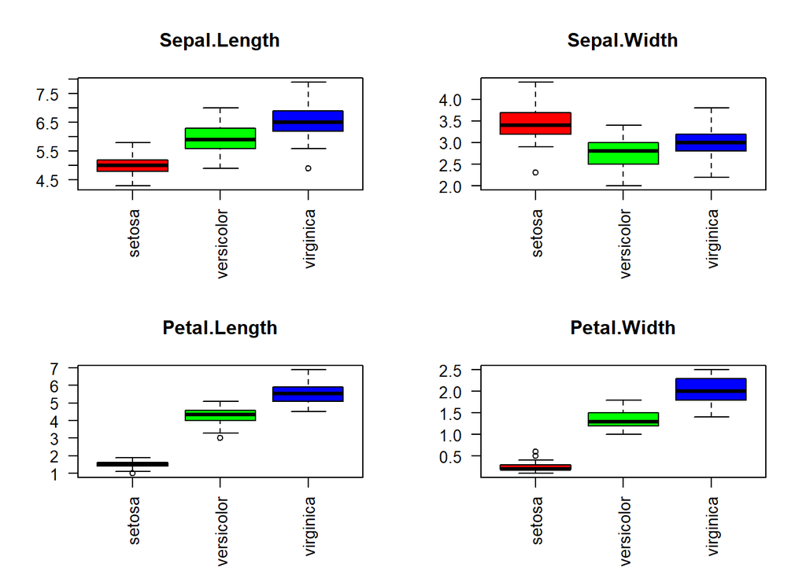

```r
par(mfrow = c(2, 2))

bp <- sapply(names(iris)[1:4], function(x) {boxplot(as.formula(paste(x, "~ Species")), data = iris, main = x, xlab = "", ylab = "", col = c("red", "green", "blue"), las = 2)})
```

### b. O pacote “vioplot” tem a função vioplot para construção de violin plots (verifique seu formato!). Construa violin plots de cada variável quantitativa do conjunto de dados, estratificando-a pelo fator Species. Remova todos os números do eixo x e usa a cor “salmon”.

Resposta

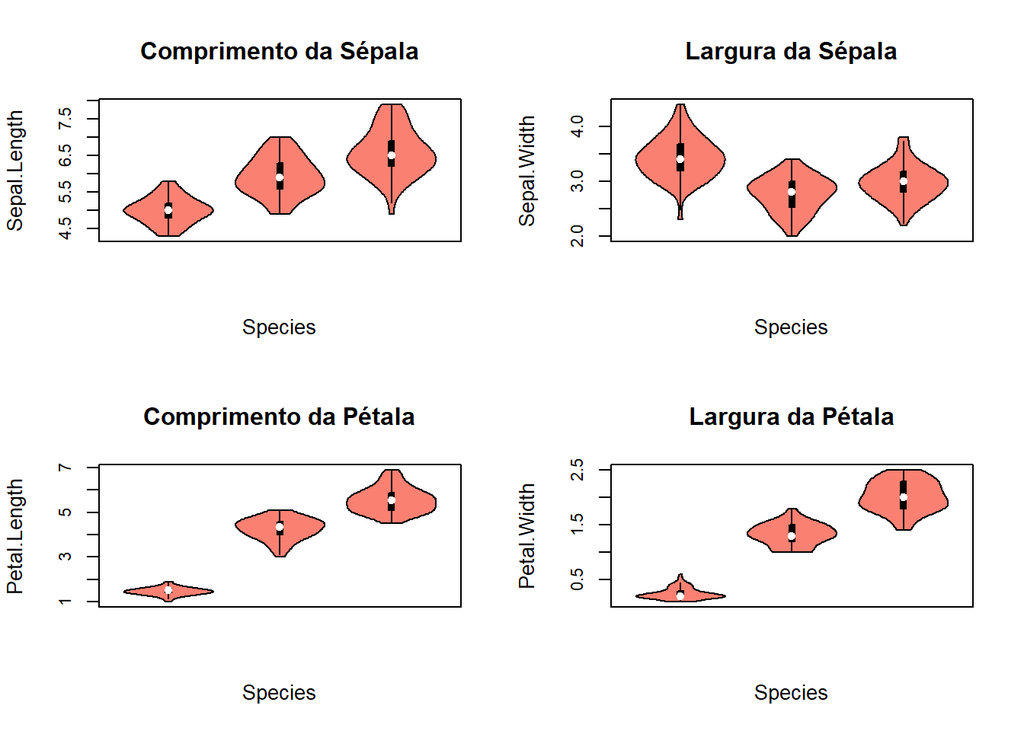

```r
library(vioplot)
par(mfrow = c(2, 2))

vioplot(Sepal.Length ~ Species, data = iris, col = "salmon", xaxt = "n", main = "Comprimento da Sépala")
vioplot(Sepal.Width ~ Species, data = iris, col = "salmon", xaxt = "n", main = "Largura da Sépala")
vioplot(Petal.Length ~ Species, data = iris, col = "salmon", xaxt = "n", main = "Comprimento da Pétala")
vioplot(Petal.Width ~ Species, data = iris, col = "salmon", xaxt = "n", main = "Largura da Pétala")
```

## 7. Classes de data frames – família apply:

### a. Descubra qual das variáveis do conjunto de dados iris não é numérica.

Resposta

Não numerico: Species

```r
lapply(iris, class)
```

```
## $Sepal.Length
## [1] "numeric"
##
## $Sepal.Width
## [1] "numeric"
##
## $Petal.Length
## [1] "numeric"
##
## $Petal.Width
## [1] "numeric"
##
## $Species
## [1] "factor"
```

### b. Identifique os níveis desse fator (utilize a função level).

Resposta

```r
lapply(iris, levels)
```

```
## $Sepal.Length
## NULL
##
## $Sepal.Width
## NULL
##
## $Petal.Length
## NULL
##
## $Petal.Width
## NULL
##
## $Species
## [1] "setosa"     "versicolor" "virginica"
```

### c. Ao invés disso, experimente a função unique e compare a saída.

Resposta

```r
unique(iris$Species)
```

```
## [1] setosa     versicolor virginica
## Levels: setosa versicolor virginica
```

### d. Repita o item (a) usando estruturas de controle. Compare o tempo entre as duas abordagens (Estruturas de controle e família apply).

Resposta

```r
va <- c()
f <- for (i in iris$Species) {
  if (!(i %in% va)) {
    va <- c(va, i)
  }
}

system.time(replicate(10000, unique(iris$Species)))
```

```
##   usuário   sistema decorrido
##      0.29      0.03      0.34
```

```r
system.time(replicate(10000, f))
```

```
##   usuário   sistema decorrido
##      0.01      0.00      0.00
```

## 8. Conjunto de dados – diamonds{ggplot2}:

### a. Quais são as colunas de classe não numérica?

Resposta

Não numéricas: cut, color e clarity

```r
library(ggplot2)
lapply(diamonds, class)
```

```
## $carat
## [1] "numeric"
##
## $cut
## [1] "ordered" "factor"
##
## $color
## [1] "ordered" "factor"
##
## $clarity
## [1] "ordered" "factor"
##
## $depth
## [1] "numeric"
##
## $table
## [1] "numeric"
##
## $price
## [1] "integer"
##
## $x
## [1] "numeric"
##
## $y
## [1] "numeric"
##
## $z
## [1] "numeric"
```

### b. Obtenha a média das colunas 8, 9 e 10 das observações 10000 a 11000.

Resposta

```r
apply(diamonds[10000:11000, 8:10], 2, mean)
```

```
##        x        y        z
## 6.237852 6.233506 3.851049
```

### c. Repita (b), arredondando para um dígito.

Resposta

```r
round(apply(diamonds[10000:11000, 8:10], 2, mean), 1)
```

```
##   x   y   z
## 6.2 6.2 3.9
```

### d. Ordene os resultados arredondados em ordem crescente.

Resposta

```r
ordered(round(apply(diamonds[10000:11000, 8:10], 2, mean), 1))
```

```
##   x   y   z
## 6.2 6.2 3.9
## Levels: 3.9 < 6.2
```

## 9. Função aggregate – Conjunto de dados – mtcars{datasets}:

### a. Calcule a mediana de cada coluna ordenada pelo número de carburadores. Use os argumentos padrão “x”, “by” e “FUN”.

Resposta

```r
aggregate(mtcars[, -11], list(carb = mtcars$carb), median, na.rm = TRUE)
```

```
##   carb   mpg cyl   disp  hp  drat    wt   qsec  vs am gear
## 1    1 22.80   4 108.00  93 3.850 2.320 19.470 1.0  1  4.0
## 2    2 22.10   4 143.75 111 3.730 3.170 17.175 0.5  0  4.0
## 3    3 16.40   8 275.80 180 3.070 3.780 17.600 0.0  0  3.0
## 4    4 15.25   8 350.50 210 3.815 3.505 17.220 0.0  0  3.5
## 5    6 19.70   6 145.00 175 3.620 2.770 15.500 0.0  1  5.0
## 6    8 15.00   8 301.00 335 3.540 3.570 14.600 0.0  1  5.0
```

### b. Repita o item(a), usando a notação ‘formula’ como argumento.

Resposta

```r
aggregate(mtcars[, -11], list(carb = mtcars$carb), function(x) median)
```

```
##   carb                                                    mpg
## 1    1 function (x, na.rm = FALSE, ...) , UseMethod("median")
## 2    2 function (x, na.rm = FALSE, ...) , UseMethod("median")
## 3    3 function (x, na.rm = FALSE, ...) , UseMethod("median")
## 4    4 function (x, na.rm = FALSE, ...) , UseMethod("median")
## 5    6 function (x, na.rm = FALSE, ...) , UseMethod("median")
## 6    8 function (x, na.rm = FALSE, ...) , UseMethod("median")
##                                                      cyl
## 1 function (x, na.rm = FALSE, ...) , UseMethod("median")
## 2 function (x, na.rm = FALSE, ...) , UseMethod("median")
## 3 function (x, na.rm = FALSE, ...) , UseMethod("median")
## 4 function (x, na.rm = FALSE, ...) , UseMethod("median")
## 5 function (x, na.rm = FALSE, ...) , UseMethod("median")
## 6 function (x, na.rm = FALSE, ...) , UseMethod("median")
##                                                     disp
```

[output cut: 55 more lines]

## 10. A função system.time retorna o tempo de operações em R. Verifique como esse comando funciona. Para uma matriz X, 107 × 2 e um vetor y de comprimento 107, calcule (algumas quantas vezes) o produto Xty, usando multiplicação de matrizes e a função crossproduct. Qual é o procedimento mais rápido?

Resposta

```r
x <- matrix(1:107, 107, 2)
y <- 1:107

system.time(replicate(10000,mapply(prod,x, y)))
```

```
##   usuário   sistema decorrido
##      1.77      0.05      1.83
```

```r
system.time(replicate(10000,crossprod(x, y)))
```

```
##   usuário   sistema decorrido
##      0.03      0.00      0.03
```